# NYCFlights: Arrival Delay Logictic Model

Shaofeng Deng

October 25, 2016

## Logsitic and Inverse Logistic Transformation

- Write an R function for the logistic function. The function should accept a `numeric` vector with values `[-Inf,Inf]` and produce a numeric vector in the the range `[0,1]`.
- Plot the logistic function from `[-10,10]`
- Write a R function for the inverse logistic function. The function should accept a `numeric` vector with values `[0,1]` and prodcuce a numeric vector in the range `[-Inf,Inf]`
- Plot the Inverse Logistic function from `[0,1]`

**Hint:** For plotting curves see `?graphics::curve` or `?ggplot2::stat_function`

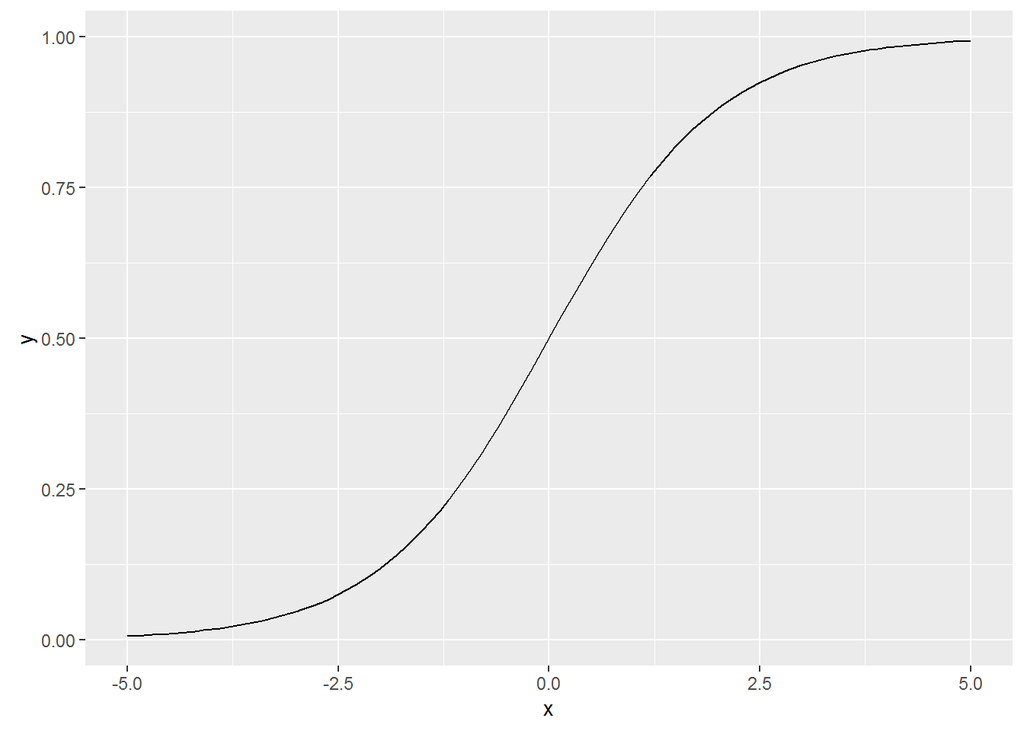

```r
l <- function(x){1/(1+exp(-x))}
ggplot(data.frame(x = c(-5, 5)), aes(x)) + stat_function(fun = l)
```

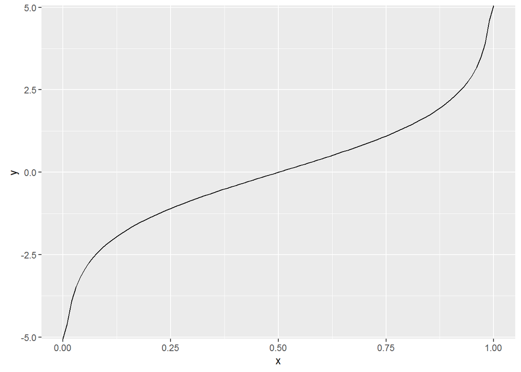

```r
inv <- function(y){-log(1/y-1)}
ggplot(data.frame(x = c(0, 1)), aes(x)) + stat_function(fun = inv)
```

# NYCFlights Model

Using the rectangular data that you created from assignment and following the *Predicting Medical Expenses* example from the text (*MLwR*), create a model for arr_delay >= 15 minutes. Follow *MLwR* structure for building a model. Describe/Explain each of the steps and show all work in codeblocks below.

KNIT YOUR DOCUMENT AS *HTML* AND SUBMIT IT AND THE `Rmd` file.

## Step 1: Collect Data

```r
yx <- read_csv("yx.csv")
yx <- yx[-1]
```

## Step 2: Explore and Prep The Data

One of the things not done in the MLwR text is a pairwise comparison between the response and each of the predictors. Make sure to do this; this is often very illustrative of the relationship between that predictor and the response. This can be done with `pairs` or `psych::panel.pairs`

## Response;

- arr_delay : right skewed, some negative
- Hypothesis: flight delays are a function of weather, mechanical problems and other factors:

## Predictors

This is reasonable list of variables that can be used

- fligths
- month **
- dep_delay (?) ***
- carrier / flight *
- origin
- dest
- air_time **
- distance ** (can make up time in the air)
- air time / hour / minute not known at end of flight
- planes
- year **
- type **
- manufacture
- engines (not much variation)
- seats
- engine **
- speed (not well populated)
- weather
- temp
- dewp
- wind_dir **+
- wind_gust **+
- precip **
- pressure **
- visib **
- airports (origin and dest)
- faa or name
- lat ** dest(only)
- lon ** dest(only)
- alt

## Remark

This step is the same as in the last homework. Here we only prepare the data.

```r
 y <- "arr_delay"
 xs <- c(
    'month','dep_delay','carrier','air_time','distance'
   ,'type','engine'
   ,'wind_dir','wind_speed','wind_gust','precip','pressure','visib'
   ,'lat.x','lon.x','lat.y','lon.y'
 )

 yx <- yx[ , c(y,xs)]

 # Remove Outliers

 yx <- yx[ yx$arr_delay >= quantile(yx$arr_delay,0.01,na.rm=TRUE) &
           yx$arr_delay <= quantile(yx$arr_delay,0.96,na.rm=TRUE), ]

 # HANDLE NA VALUES
 yx <- yx[complete.cases(yx),]

 # Change arr_delay to logical
 yx$arr_delay <- yx$arr_delay >= 15
```

## Step 3: Train The Model

Our naive guess is: 0.5454484

Our naive rmse is: 0.4979302

```r
model <- glm(arr_delay ~.,family=binomial(link='logit'),data=yx %>% sample_n(1e5))
model
```

```
##
## Call:  glm(formula = arr_delay ~ ., family = binomial(link = "logit"),
##     data = yx %>% sample_n(1e+05))
##
## Coefficients:
##                  (Intercept)                         month
##                   -6.239e+01                     1.842e-02
##                    dep_delay                     carrierAA
##                    1.345e-01                     9.908e-02
##                    carrierAS                     carrierB6
##                    1.494e-01                     6.965e-01
##                    carrierDL                     carrierEV
##                    2.503e-01                     5.521e-01
##                    carrierF9                     carrierFL
##                    9.231e-01                     1.200e+00
##                    carrierHA                     carrierMQ
##                    2.687e+00                     1.048e+00
##                    carrierOO                     carrierUA
##                    5.804e-01                    -6.955e-03
##                    carrierUS                     carrierVX
##                    9.218e-01                    -1.858e-01
##                    carrierWN                     carrierYV
##                   -2.975e-01                     7.576e-01
##                     air_time                      distance
##                    9.618e-02                    -1.202e-02
## typeFixed wing single engine                typeRotorcraft
##                   -4.003e-01                     3.770e+00
##          engineReciprocating               engineTurbo-fan
##                    4.061e+00                     3.671e+00
##              engineTurbo-jet              engineTurbo-prop
##                    3.860e+00                     4.019e+00
##            engineTurbo-shaft                      wind_dir
##                           NA                    -1.858e-03
##                   wind_speed                     wind_gust
##                    4.831e+02                    -4.198e+02
##                       precip                      pressure
##                           NA                    -2.108e-02
##                        visib                         lat.x
##                   -7.262e-04                     2.003e+00
##                        lon.x                         lat.y
##                    5.804e-02                    -1.673e-02
##                        lon.y
##                    1.606e-02
##
## Degrees of Freedom: 99999 Total (i.e. Null);  99965 Residual
## Null Deviance:       99040
## Residual Deviance: 46260     AIC: 46330
```

## Step 4: Evaluate Performance

Think about some of the tools that you have for evaluating performance. Choose one and articulate why you have chosen it.

```r
anova(model, test="Chisq")
```

```
## Analysis of Deviance Table
##
## Model: binomial, link: logit
##
## Response: arr_delay
##
## Terms added sequentially (first to last)
##
##
##            Df Deviance Resid. Df Resid. Dev  Pr(>Chi)
## NULL                       99999      99040
## month       1       40     99998      99000 2.237e-10 ***
## dep_delay   1    42392     99997      56608 < 2.2e-16 ***
## carrier    15      435     99982      56173 < 2.2e-16 ***
## air_time    1      336     99981      55838 < 2.2e-16 ***
## distance    1     9007     99980      46831 < 2.2e-16 ***
## type        2        0     99978      46831 0.8888649
## engine      4       15     99974      46815 0.0042876 **
## wind_dir    1      171     99973      46644 < 2.2e-16 ***
## wind_speed  1       11     99972      46633 0.0009387 ***
## wind_gust   1        2     99971      46631 0.2005974
## precip      0        0     99971      46631
## pressure    1      166     99970      46465 < 2.2e-16 ***
## visib       1        0     99969      46465 0.8785958
## lat.x       1       64     99968      46402 1.543e-15 ***
## lon.x       1        1     99967      46401 0.3408753
## lat.y       1      131     99966      46270 < 2.2e-16 ***
## lon.y       1        7     99965      46262 0.0066162 **
## ---
## Signif. codes:  0 '***' 0.001 '**' 0.01 '*' 0.05 '.' 0.1 ' ' 1
```

The difference between the null deviance and the residual deviance shows how our model is doing against the null model (a model with only the intercept). The wider this gap, the better. Analyzing the table we can see the drop in deviance when adding each variable one at a time. Most of the varibles seem to significantly reduce the residual deviance.

## I can only get this far in 2 hours

## Step 5: Improve Performance

Show some steps for improving model performance.

# Question:

# PART B:

Your model should be good at explaining tardiness. Now, assume that your job is to predict arrival delays a month in advance. You can no longer use all the features in your model. Retrain your model using only features that will be *known* only a month in advance of the departure time. Show all steps as above.